# Youth Smoking and Quitline Analysis

### by Breton Shindel

[figure not shown]

```python
from IPython.display import Image

Image(filename='breakfast_club_image.jpg')
```

## Abstract

This report will explore the relationships between youth cigarette smoking trends and quitline call center trends across US states over time. The data was taken from the Center for Diseace COntrol (CDC) from 2010 through 2014. Information on each dataset is as follows:

### Youth Tobacco Survey:

1999-2014, Center for Disease Control and Prevention (CDC). State Tobacco Activities Tracking and Evaluation (STATE) System. YTS Data. The YTS was developed to provide states with comprehensive data on both middle school and high school students regarding tobacco use, exposure to environmental tobacco smoke, smoking cessation, school curriculum, minors' ability to purchase or otherwise obtain tobacco products, knowledge and attitudes about tobacco, and familiarity with pro-tobacco and anti-tobacco media messages. The YTS uses a two-stage cluster sample design to produce representative samples of students in middle schools (grades 6–8) and high schools (grades 9–12). The data for the STATE System were extracted from Youth Tobacco Surveys from participating states. Tobacco topics included are cigarette smoking prevalence, cigarette smoking frequency, smokeless tobacco products prevalence and quit attempts.

YTS Survey: http://www.cdc.gov/tobacco/data_statistics/surveys/yts/index.htm

### Quitline Call Center Data:

2010-2015, National Quitline Data Warehouse (NQDW). State Tobacco Activities Tracking and Evaluation (STATE) System. NQDW Data. National Quitline Data Warehouse (NQDW) assists in evaluating quitline activities and serves as a national resource for data on the use, success, and services of state quitlines. States report data on quitline callers, quitting success, as well as the services provided by their quitlines. The NQDW consolidates this information for evaluating programs and improving quitline services. The jurisdictions participating in this data collection effort include the 50 states, the District of Columbia, Guam and Puerto Rico.

Quitline data warehouse: http://www.cdc.gov/tobacco/quit_smoking/cessation/nqdw/

## Initial Argument

I predict that over time youth smoking has slowly been declining across each US state, while any change in quitline calls will be modest, there will be some type of relationship between quitline calls and youth smoking trends.

```python
from IPython.display import HTML

HTML('''<script>
code_show=true;
function code_toggle() {
 if (code_show){
 $('div.input').hide();
 } else {
 $('div.input').show();
 }
 code_show = !code_show
}
$( document ).ready(code_toggle);
</script>
<form action="javascript:code_toggle()"><input type="submit" value="Click here to toggle on/off the raw code."></form>''')
```

```python
import pandas as pd
import numpy as np
import matplotlib.pyplot as plt
import seaborn as sns
import warnings
warnings.filterwarnings('ignore')

%cd ~/PythonAnalytics/
```

```
/Users/bretonshindel/PythonAnalytics
```

```python
Survey = pd.read_csv('Youth_Tobacco_Survey__YTS__Data.csv')

#Drop unnecessary features
Survey = Survey.drop(['LocationDesc', 'DataSource', 'Data_Value_Unit', 'Data_Value_Footnote_Symbol',
                      'Data_Value_Footnote', 'TopicTypeId', 'TopicId', 'MeasureId', 'StratificationID1',
                      'StratificationID2', 'StratificationID3', 'StratificationID4'], axis = 1)
#Rename features
Survey = Survey.rename(columns={'YEAR':'Year', 'LocationAbbr':'State'})
Survey = Survey.dropna()

#Fixing the Date data
col_name = Survey.columns[0]
Survey = Survey.rename(columns = {col_name:'Year'})
Survey = Survey[Survey['Year'] > 2009]
Survey.Year = pd.to_datetime(Survey.Year, format='%Y')

#Changing geographic data format
Survey['GeoLocation'] = Survey['GeoLocation'].str.replace('(', '')
Survey['GeoLocation'] = Survey['GeoLocation'].str.replace(',', '')
Survey['GeoLocation'] = Survey['GeoLocation'].str.replace(')', '')
Locations = Survey['GeoLocation'].str.split(' ', return_type='frame').astype(float)
#Seperate the Location data to create Longitude and Latitude
Locations = Locations.round(4)
Survey = pd.concat([Survey, Locations], axis=1, join='outer')
Survey = Survey.rename(columns={0: 'Latitude', 1: 'Longitude'})
Survey = Survey.drop('GeoLocation', axis=1)
```

```python
Quitline = pd.read_csv('Quitline___Service_Utilization_-_2010_To_Present.csv')

#Drop unnecessary features
Quitline = Quitline.drop(['LocationDesc', 'TopicType', 'TopicTypeId', 'TopicId', 'MeasureID',
                          'SOURCE'], axis = 1)
#Rename features
Quitline = Quitline.rename(columns={'Year':'Year', 'LocationAbbr':'State'})

#Fixing date data
col_name2 = Quitline.columns[0]
Quitline = Quitline.rename(columns = {col_name2:'Year'})
Quitline = Quitline[Quitline['Year'] < 2015]
Quitline.Year = pd.to_datetime(Quitline.Year, format='%Y')

#Changing geographic data format
Quitline['GeoLocation'] = Quitline['GeoLocation'].str.replace('(', '')
Quitline['GeoLocation'] = Quitline['GeoLocation'].str.replace(',', '')
Quitline['GeoLocation'] = Quitline['GeoLocation'].str.replace(')', '')
Locations = Quitline['GeoLocation'].str.split(' ', return_type='frame').astype(float)
#Seperate the Location data to create Longitude and Latitude
Locations = Locations.round(4)
Quitline = pd.concat([Quitline, Locations], axis=1, join='outer')
Quitline = Quitline.rename(columns={0: 'Latitude', 1: 'Longitude'})
Quitline = Quitline.drop('GeoLocation', axis=1)
```

# Visualizing the Survey Data

We can see below that there is a large gap in percentages across states, ranging as high as nearly 8% of all youth takers in the state rating themselves as 'frequent smokers' to almost 0%. Let's examine how this trend has shaped itself over time.

```python
%matplotlib inline

sns.set_context('poster')
sns.mpl.rc("figure", figsize=(12,8))
```

```python
Set = Survey[['State', 'TopicDesc', 'Response', 'Data_Value']]
Set = Set[Set['TopicDesc'] == 'Cigarette Use (Youth)']
Set = Set[Set['Response'] == 'Frequent']

Set2 = Set.groupby('State', as_index=True).agg({'Data_Value':np.mean})
Set2 = Set2.sort_values(by='Data_Value', ascending=False)
```

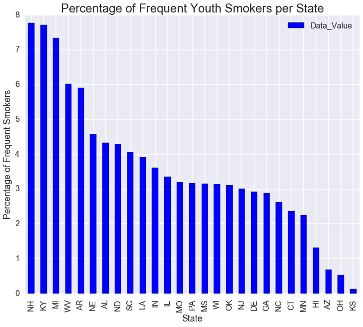

```python
sns.mpl.rc("figure", figsize=(12,10))

Set2.plot.bar()
plt.ylabel('Percentage of Frequent Smokers')
plt.title('Percentage of Frequent Youth Smokers per State', size=24);
```

In the following graphics, I've aggregated the youth smoker data by taking the mean of the total states' data per year. Yellow represents youth who have ever smoked up to the survey, orange represents youth who currently smoke at the time of the survey, and red represents youth who frequently smoke at the time of the survey.

```python
Freq_Year = Survey[['State', 'Year', 'TopicDesc', 'Response', 'Data_Value']]
Freq_Year = Freq_Year[Freq_Year['TopicDesc'] == 'Cigarette Use (Youth)']
Freq_Year = Freq_Year[Freq_Year['Response'] == 'Frequent']
Freq_Year_T = Freq_Year.pivot_table('Data_Value', index='Year')

Ever_Year = Survey[['State', 'Year', 'TopicDesc', 'Response', 'Data_Value']]
Ever_Year = Ever_Year[Ever_Year['Response'] == 'Ever']
Ever_Year_T = Ever_Year.pivot_table('Data_Value', index='Year')

Current_Year = Survey[['State', 'Year', 'TopicDesc', 'Response', 'Data_Value']]
Current_Year = Current_Year[Current_Year['Response'] == 'Current']
Current_Year_T = Current_Year.pivot_table('Data_Value', index='Year')
```

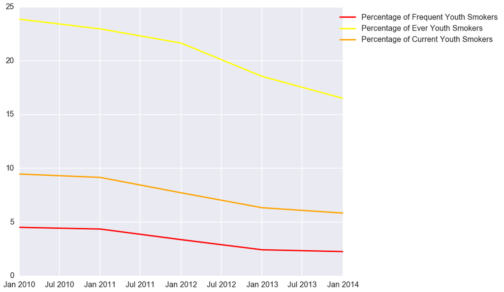

```python
ax = plt.subplot(111)
sns.mpl.rc("figure", figsize=(12,10))

plt.plot(Freq_Year_T, color='red', label='Percentage of Frequent Youth Smokers')
plt.plot(Ever_Year_T, color='yellow', label='Percentage of Ever Youth Smokers')
plt.plot(Current_Year_T, color='orange', label='Percentage of Current Youth Smokers')

ax.legend(bbox_to_anchor=(1.5, 1))
plt.show();
```

Next, can we narrow this down further to visualize smoking patterns in each state? Yes, but unfortunately were are two major issues with deriving this information. First, the survey has never been distributed in half the US states, so we can't get a true state-wide graphic on youth smoking trends. Furthermore, looking at the dataframe below, you'll notice that many of the values are missing. This is another major issue. Creating time series plots or scatter plots for each state show virtually no information, and the missing data appears to be arbitrary across states and years so we can't simply visualize the difference between a state in 2010 vs. 2014. A final caveat to all of these visualizations is that we are only displaying data scross a 5-year time frame. While we can make global assumptions from this data, we cannot derive any conclusions backed by robust statistical significance.

```python
States_Freq = Freq_Year.pivot_table('Data_Value', index = 'State', columns = 'Year')

States_Freq2 = Freq_Year.pivot_table('Data_Value', index = 'Year', columns = 'State')
States_Freq2.head(3)
```

| State Year | AL | AR | AZ | CT | DE | GA | HI | IL | IN | KS | ... | ND | NE | NH | NJ | OH | OK | PA | SC | WI | WV |
| --- | --- | --- | --- | --- | --- | --- | --- | --- | --- | --- | --- | --- | --- | --- | --- | --- | --- | --- | --- | --- | --- |
| 2010-01-01 | 4.600000 | 5.9 | NaN | NaN | 3.483333 | NaN | NaN | 4.233333 | 3.966667 | NaN | ... | NaN | NaN | NaN | 5.366667 | 0.800000 | NaN | 4.466667 | NaN | 3.716667 | NaN |
| 2011-01-01 | NaN | NaN | 0.933333 | 2.8 | NaN | 3.7 | 1.816667 | NaN | NaN | NaN | ... | 5.016667 | NaN | 7.766667 | NaN | NaN | 4.216667 | NaN | 5.066667 | NaN | 6.8 |
| 2012-01-01 | 4.583333 | NaN | NaN | NaN | 3.183333 | NaN | NaN | NaN | NaN | NaN | ... | NaN | 5.033333 | NaN | 3.533333 | 0.433333 | NaN | NaN | NaN | 2.566667 | NaN |

3 rows × 27 columns

Despite the missing and inconsistent data, we will move forward and visualize heatmaps of each state's percentage of smokers (frequent, current, and ever) over the 5 year time period.

```python
AL_Freq = States_Freq.loc['AL']
DE_Freq = States_Freq.loc['DE']
MN_Freq = States_Freq.loc['MN']
MS_Freq = States_Freq.loc['MS']
NE_Freq = States_Freq.loc['NE']
NJ_Freq = States_Freq.loc['NJ']
OH_Freq = States_Freq.loc['OH']
PA_Freq = States_Freq.loc['PA']
AZ_Freq = States_Freq.loc['AZ']
CT_Freq = States_Freq.loc['CT']
GA_Freq = States_Freq.loc['GA']
HI_Freq = States_Freq.loc['HI']
IL_Freq = States_Freq.loc['IL']
IN_Freq = States_Freq.loc['IN']
KS_Freq = States_Freq.loc['KS']
LA_Freq = States_Freq.loc['LA']
MO_Freq = States_Freq.loc['MO']
NC_Freq = States_Freq.loc['NC']
ND_Freq = States_Freq.loc['ND']
OK_Freq = States_Freq.loc['OK']
SC_Freq = States_Freq.loc['SC']
WV_Freq = States_Freq.loc['WV']
WI_Freq = States_Freq.loc['WI']
MI_Freq = States_Freq.loc['MI']
NH_Freq = States_Freq.loc['NH']
AR_Freq = States_Freq.loc['AR']
KY_Freq = States_Freq.loc['KY']
```

```python
States_Current = Current_Year.pivot_table('Data_Value', index = 'State', columns = 'Year')
States_Ever = Ever_Year.pivot_table('Data_Value', index = 'State', columns = 'Year')
```

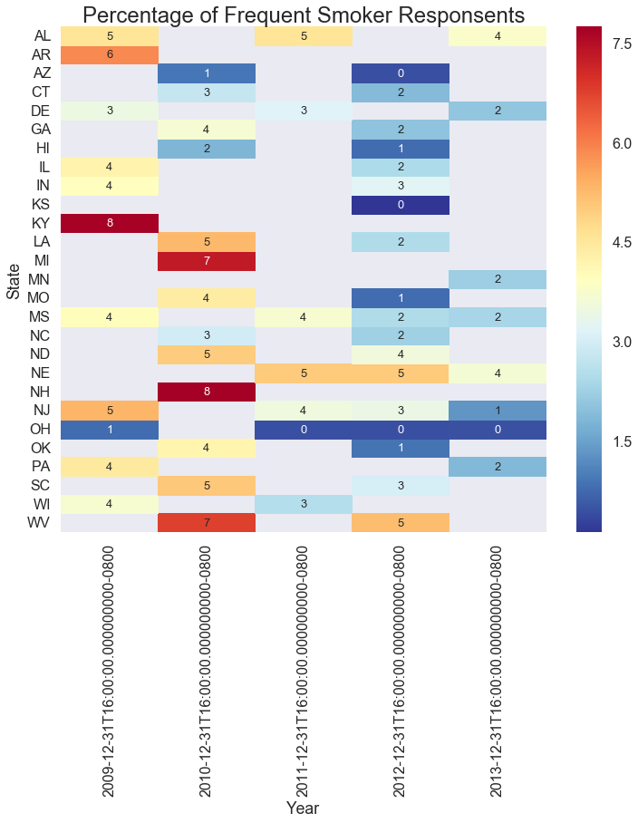

```python
sns.heatmap(States_Freq, cmap= 'RdYlBu_r', annot= True, fmt=',.0f', annot_kws={'fontsize':13})

plt.title('Percentage of Frequent Smoker Responsents', size=24)
plt.show();
```

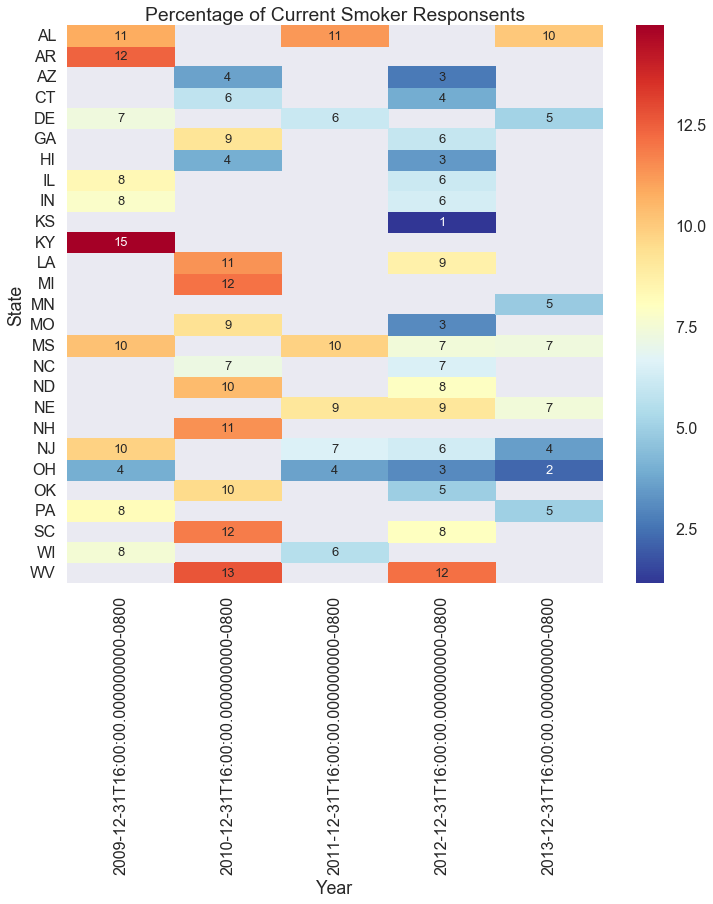

```python
sns.heatmap(States_Current, cmap= 'RdYlBu_r', annot= True, fmt=',.0f', annot_kws={'fontsize':13})

plt.title('Percentage of Current Smoker Responsents')
plt.show();
```

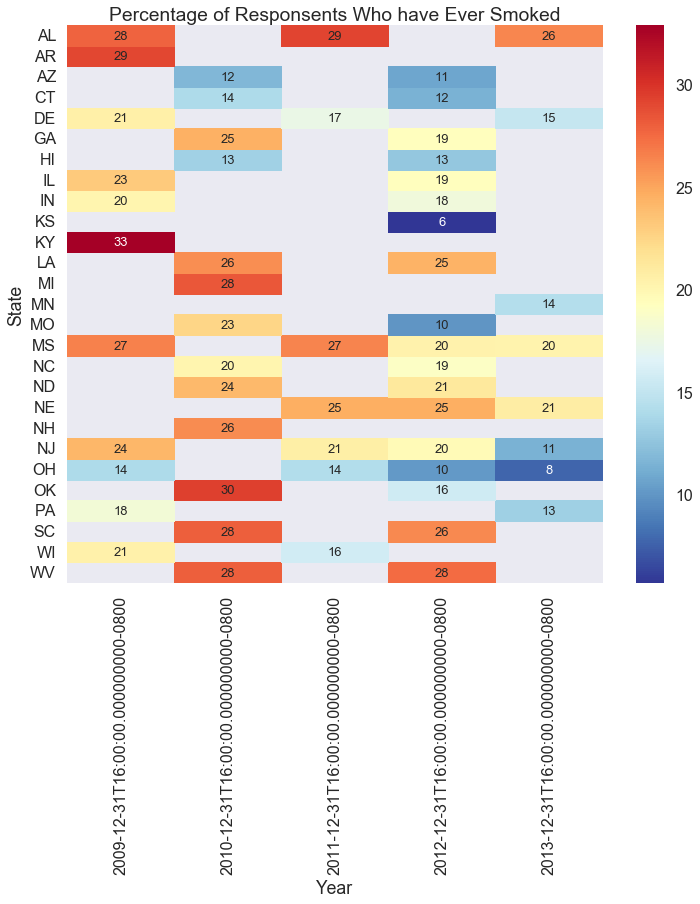

```python
sns.heatmap(States_Ever, cmap= 'RdYlBu_r', annot= True, fmt=',.0f', annot_kws={'fontsize':13})

plt.title('Percentage of Responsents Who have Ever Smoked')
plt.show();
```

What's great about these heatmaps is that we can see the trend across every single represented state, that rates of smoking are decreasing across every measurement. Looking at each specific state, there is not a single instance in all three heat maps where percentages increased between the earliest record and the latest. Can we take these findings at face value? Maybe. This survey is missing heaps of data, and although their sample sizes were generally large across each survey, the lack of consistency across state and year data makes this dataset difficult to trust. Personalliy, while **I do not trust the data, I trust the trend.**

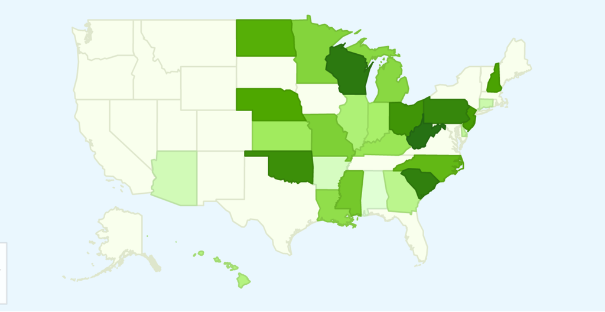

```python
Image(filename='Screen Shot 2016-04-14 at 3.24.32 PM.png')
```

Next we will see how smokeless tobacco use has changed year by year amoung the youth across states. Same as above, we have aggregated this data by the mean across each year.

```python
S_Freq_Year = Survey[['State', 'Year', 'TopicDesc', 'Response', 'Data_Value']]
S_Freq_Year = S_Freq_Year[S_Freq_Year['TopicDesc'] == 'Smokeless Tobacco Use (Youth)']
S_Freq_Year = S_Freq_Year[S_Freq_Year['Response'] == 'Frequent']
S_Freq_Year_T = S_Freq_Year.pivot_table('Data_Value', index='Year')

S_Ever_Year = Survey[['State', 'Year', 'TopicDesc', 'Response', 'Data_Value']]
S_Ever_Year = S_Ever_Year[S_Ever_Year['TopicDesc'] == 'Smokeless Tobacco Use (Youth)']
S_Ever_Year = S_Ever_Year[S_Ever_Year['Response'] == 'Ever']
S_Ever_Year_T = S_Ever_Year.pivot_table('Data_Value', index='Year')

S_Current_Year = Survey[['State', 'Year', 'TopicDesc', 'Response', 'Data_Value']]
S_Current_Year = S_Current_Year[S_Current_Year['TopicDesc'] == 'Smokeless Tobacco Use (Youth)']
S_Current_Year = S_Current_Year[S_Current_Year['Response'] == 'Current']
S_Current_Year_T = S_Current_Year.pivot_table('Data_Value', index='Year')
```

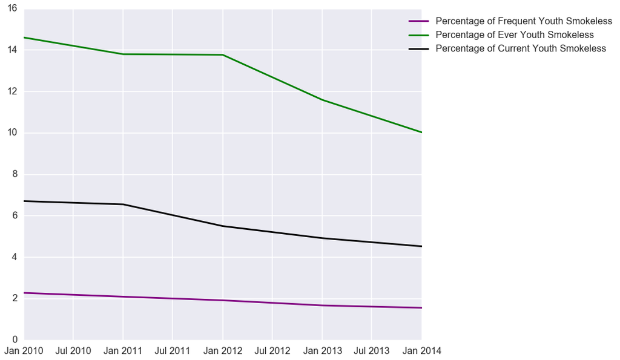

```python
ax = plt.subplot(111)
sns.mpl.rc("figure", figsize=(12,10))

plt.plot(S_Freq_Year_T, color='purple', label='Percentage of Frequent Youth Smokeless')
plt.plot(S_Ever_Year_T, color='green', label='Percentage of Ever Youth Smokeless')
plt.plot(S_Current_Year_T, color='black', label='Percentage of Current Youth Smokeless')

ax.legend(bbox_to_anchor=(1.5, 1))
plt.show();
```

The good news is not limited just to cigarette use. The decline of tobacco consumption by our youth is decreasing on every field.

```python
Volume = Quitline[Quitline['Measure'] == 'Call Volume']
Volume2 = Volume.groupby('State', as_index=True).agg({'Value':np.mean})
Volume2 = Volume2.drop('US', axis=0)
Volume2 = Volume2.sort_values('Value', ascending=False)
```

# Visualizing the Quitline Data

The Quitline data was quite difficult to derive good understanding from. The benefits of working with a dataset that is fully aggregated and prepared is that in theory it can save you a lot of time filtering, cleaning, aggregating and more. The downside of this is that the dataset doesn't always tell you what you need to know. I've had a lot of difficulty deriving good insights from the quitline dataset provided; however there is one important visualization below.

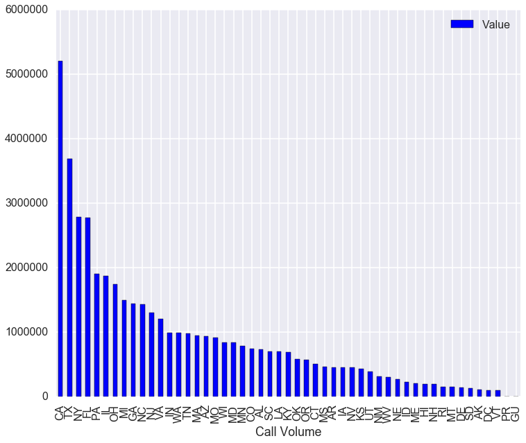

```python
Volume2.plot.bar()

plt.xlabel('Call Volume')
plt.show();
```

```python
Volume3 = Volume[Volume['Variable'] == 'Total Incoming Calls']
Volume3_T = Volume3.pivot_table('Value', index='Year')
Volume3_Ag = Volume3.groupby('Year', as_index=True).agg({'Value':np.mean})
```

```python
Freq_Year_M = Freq_Year.groupby('Year', as_index=True).agg({'Data_Value':np.mean})
```

```python
Volume3_T_Mean = (Volume3_T - np.mean(Volume3_T))/np.std(Volume3_T)
Freq_Year_Mean = (Freq_Year_T - np.mean(Freq_Year_T))/np.std(Freq_Year_T)

Freq_Year_Mean
```

```
Year
2010-01-01    1.202293
2011-01-01    1.034848
2012-01-01   -0.015750
2013-01-01   -1.021134
2014-01-01   -1.200257
Name: Data_Value, dtype: float64
```

```python
Volume3_T_MM = (Volume3_T - Volume3_T.min(axis=0)) / (Volume3_T.max(axis=0) - Volume3_T.min(axis=0))
Freq_Year_MM = (Freq_Year_T - Freq_Year_T.min(axis=0)) / (Freq_Year_T.max(axis=0) - Freq_Year_T.min(axis=0))
```

```python
Freq_Year_Mean
```

[output not shown]

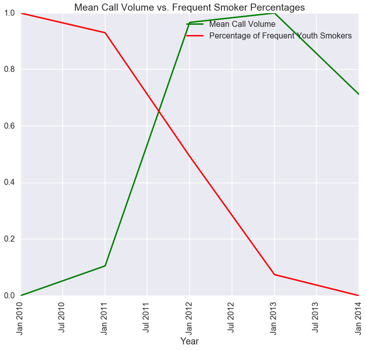

```python
#ax = plt.subplot(111)
#ax.set_yscale("log", nonposy='clip')

plt.plot(Volume3_T_MM, color='green', label='Mean Call Volume')
plt.plot(Freq_Year_MM, color='red', label='Percentage of Frequent Youth Smokers')

plt.title('Mean Call Volume vs. Frequent Smoker Percentages')
plt.xlabel('Year')
plt.xticks(rotation = 90)
plt.legend(loc='upper right')
plt.show();
```

We can see here that there has been a strong trend upward of quitline call volume across the US. Due to our narrow timeline of data collection, this is by no means trying to show a dramatic trend over a long period of time; however, it indicates an inverse correlation could exist between volume of calls to a quitline center, and use of tobacco use by our nation's youth. Correlation does not mean causation, but it could indicate that our quitline service is serving its purpose.

# Conclusion

In conclusion my opening argument has been modified since the start of the project. Indeed the rates of youth smokers and tobacco users has been declining over time, and indeed there appears to be a correlation between quitline call volume and use of tobacco products among our youth. What has changed is that the quitline call volume has NOT been relatively even or steady across years, with a charp increase of more than 3000 calls from 2011 to 2012 and later on a smalled decrease by a little less than 1000 calls from 2013 to 2014.

The data is spanned between too short a time period, and has too many missing values and inconsistencies to derive a robust finding from it, but we can plainly see that there is news to celebrate. Youth tobacco use is indeed in decline, and the services provided by our national quitline centers may be playing a significant role in that decline.